# Project Practical Machine Learning

Dweepobotee Brahma

## Introduction

This is the project report for Coursera’s Practical Machine Learning Course. In this project the Human Activity Recognition dataset is used to evaluate how well participants perform exercises. I use data from 6 participants’ activities from using accelerometers on the belt, forearm, arm, and dumbell.The participants were asked to perform barbell lifts correctly and incorrectly in five different ways and this information was recorded in the ‘classe’ variable. In this analysis I fit different models to predict the ‘classe’ variable.

## Data Processing

### Importing the data

First the following packages are loaded.

```r
library(caret)
```

```r
library(rpart)
library(rpart.plot)
library(RColorBrewer)
library(rattle)
library(randomForest)
library(knitr)
```

Next we import the dataset.

```r
trainurl<-"https://d396qusza40orc.cloudfront.net/predmachlearn/pml-training.csv"
testurl<-"https://d396qusza40orc.cloudfront.net/predmachlearn/pml-testing.csv"
train<-read.csv(url(trainurl), na.strings=c("NA","#DIV/0!", ""))
test<-read.csv(url(testurl), na.strings=c("NA", "#DIV/0!", ""))
```

### Cleaning the data

First the columns containing missing observations are deleted.

```r
train<-train[,colSums(is.na(train))==0]
test<-test[,colSums(is.na(test))==0]
```

Next, the first 7 columns are removed because they dont have any information relevant to prediction.

```r
train<-train[, -c(1:7)]
test<-test[, -c(1:7)]
```

```r
dim(train)
```

```
## [1] 19622    53
```

```r
dim(test)
```

```
## [1] 20 53
```

### Data Splitting

```r
set.seed(1705)
createtrain<-createDataPartition(train$classe, p=0.6, list=FALSE)
train<-train[createtrain,]
valid<-train[-createtrain,]
```

## Prediction Models

### Classification Tree

We first fit a classification tree to the dataset. We perform 5-fold cross validation which will save computing time since the dataset is moderately large.

```r
control<-trainControl(method="cv", number=5)
fit.rpart<-train(classe~.,data=train, method="rpart", trControl=control)
print(fit.rpart)
```

```
## CART
##
## 11776 samples
##    52 predictor
##     5 classes: 'A', 'B', 'C', 'D', 'E'
##
## No pre-processing
## Resampling: Cross-Validated (5 fold)
## Summary of sample sizes: 9422, 9420, 9420, 9421, 9421
## Resampling results across tuning parameters:
##
##   cp          Accuracy   Kappa
##   0.02226705  0.5827025  0.46710109
##   0.03405316  0.5390561  0.40645128
##   0.11782155  0.3327077  0.07402507
##
## Accuracy was used to select the optimal model using  the largest value.
## The final value used for the model was cp = 0.02226705.
```

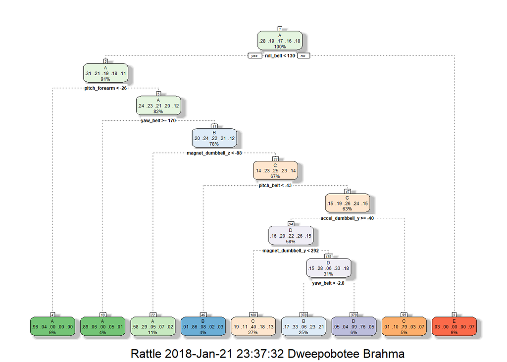

```r
fancyRpartPlot(fit.rpart$finalModel)
```

Using this fitted classification tree we try to predict the outcomes in the validation set.

```r
predict.valid<-predict(fit.rpart, valid)
```

Displaying the prediction results.

```r
conf.valid<-confusionMatrix(valid$classe,predict.valid)
(accuracy.valid<-conf.valid$overall[1])
```

```
##  Accuracy
## 0.5841102
```

### Random Forest

To improve the prediction performance we fit a random forest model next.

```r
fit.rf<-train(classe~., data=train, method="rf", trControl=control)
print(fit.rf)
```

```
## Random Forest
##
## 11776 samples
##    52 predictor
##     5 classes: 'A', 'B', 'C', 'D', 'E'
##
## No pre-processing
## Resampling: Cross-Validated (5 fold)
## Summary of sample sizes: 9421, 9420, 9422, 9420, 9421
## Resampling results across tuning parameters:
##
##   mtry  Accuracy   Kappa
##    2    0.9889611  0.9860341
##   27    0.9894696  0.9866778
##   52    0.9840347  0.9797994
##
## Accuracy was used to select the optimal model using  the largest value.
## The final value used for the model was mtry = 27.
```

Using this fitted random forest model we try ro predict the outcomes of the validation set.

```r
predict.rf<-predict(fit.rf,valid)
(conf.rf<-confusionMatrix(valid$classe,predict.rf))
```

```
## Confusion Matrix and Statistics
##
##           Reference
## Prediction    A    B    C    D    E
##          A 1354    0    0    0    0
##          B    0  901    0    0    0
##          C    0    0  817    0    0
##          D    0    0    0  776    0
##          E    0    0    0    0  872
##
## Overall Statistics
##
##                Accuracy : 1
##                  95% CI : (0.9992, 1)
##     No Information Rate : 0.2869
##     P-Value [Acc > NIR] : < 2.2e-16
##
##                   Kappa : 1
##  Mcnemar's Test P-Value : NA
##
## Statistics by Class:
##
##                      Class: A Class: B Class: C Class: D Class: E
## Sensitivity            1.0000   1.0000   1.0000   1.0000   1.0000
## Specificity            1.0000   1.0000   1.0000   1.0000   1.0000
## Pos Pred Value         1.0000   1.0000   1.0000   1.0000   1.0000
## Neg Pred Value         1.0000   1.0000   1.0000   1.0000   1.0000
## Prevalence             0.2869   0.1909   0.1731   0.1644   0.1847
## Detection Rate         0.2869   0.1909   0.1731   0.1644   0.1847
## Detection Prevalence   0.2869   0.1909   0.1731   0.1644   0.1847
## Balanced Accuracy      1.0000   1.0000   1.0000   1.0000   1.0000
```

```r
(accuracy.rf<-conf.rf$overall[1])
```

```
## Accuracy
##        1
```

## Prediction on test set

Using our fitted random forest model we predict our test set.

```r
(predict(fit.rf,test))
```

```
##  [1] B A B A A E D B A A B C B A E E A B B B
## Levels: A B C D E
```

This concludes the project for this course.